# **Marketing Campaign Analysis**

## **Problem Definition**

### **The Context:**

- Why is this problem important to solve?

### **The objective:**

- What is the intended goal?

### **The key questions:**

- What are the key questions that need to be answered?

### **The problem formulation**:

- What is it that we are trying to solve using data science?

## **Data Dictionary**

The dataset contains the following features:

1. ID: Unique ID of each customer
2. Year_Birth: Customer’s year of birth
3. Education: Customer's level of education
4. Marital_Status: Customer's marital status
5. Kidhome: Number of small children in customer's household
6. Teenhome: Number of teenagers in customer's household
7. Income: Customer's yearly household income in USD
8. Recency: Number of days since the last purchase
9. Dt_Customer: Date of customer's enrollment with the company
10. MntFishProducts: The amount spent on fish products in the last 2 years
11. MntMeatProducts: The amount spent on meat products in the last 2 years
12. MntFruits: The amount spent on fruits products in the last 2 years
13. MntSweetProducts: Amount spent on sweet products in the last 2 years
14. MntWines: The amount spent on wine products in the last 2 years
15. MntGoldProds: The amount spent on gold products in the last 2 years
16. NumDealsPurchases: Number of purchases made with discount
17. NumCatalogPurchases: Number of purchases made using a catalog (buying goods to be shipped through the mail)
18. NumStorePurchases: Number of purchases made directly in stores
19. NumWebPurchases: Number of purchases made through the company's website
20. NumWebVisitsMonth: Number of visits to the company's website in the last month
21. AcceptedCmp1: 1 if customer accepted the offer in the first campaign, 0 otherwise
22. AcceptedCmp2: 1 if customer accepted the offer in the second campaign, 0 otherwise
23. AcceptedCmp3: 1 if customer accepted the offer in the third campaign, 0 otherwise
24. AcceptedCmp4: 1 if customer accepted the offer in the fourth campaign, 0 otherwise
25. AcceptedCmp5: 1 if customer accepted the offer in the fifth campaign, 0 otherwise
26. Response: 1 if customer accepted the offer in the last campaign, 0 otherwise
27. Complain: 1 If the customer complained in the last 2 years, 0 otherwise

**Note:** You can assume that the data is collected in the year 2016.

## **Import the necessary libraries and load the data**

```python
import warnings
warnings.filterwarnings('ignore')
from sklearn.cluster import KMeans
from sklearn.metrics import silhouette_score
import matplotlib.pyplot as plt
from sklearn_extra.cluster import KMedoids
from datetime import datetime
from sklearn.cluster import DBSCAN

import scipy.cluster.hierarchy as sch
from scipy.spatial.distance import pdist
from sklearn.mixture import GaussianMixture
from scipy.cluster.hierarchy import cophenet
import matplotlib.pyplot as plt
import numpy as np
import pandas as pd
import matplotlib.pyplot as plt
%matplotlib inline
import seaborn as sns
from scipy.stats import chi2_contingency
from sklearn.preprocessing import StandardScaler
from sklearn.manifold import TSNE
from sklearn.decomposition import PCA

data = pd.read_csv('/Users/christiansamson/Documents/School/MIT/Data Analytics/Marketing Campaign Customer Segmentation/Final/marketing_campaign+%284%29.csv')
print(data.head())
```

```
     ID  Year_Birth   Education Marital_Status   Income  Kidhome  Teenhome  \
0  5524        1957  Graduation         Single  58138.0        0         0
1  2174        1954  Graduation         Single  46344.0        1         1
2  4141        1965  Graduation       Together  71613.0        0         0
3  6182        1984  Graduation       Together  26646.0        1         0
4  5324        1981         PhD        Married  58293.0        1         0

  Dt_Customer  Recency  MntWines  ...  NumCatalogPurchases  NumStorePurchases  \
0  04-09-2012       58       635  ...                   10                  4
1  08-03-2014       38        11  ...                    1                  2
2  21-08-2013       26       426  ...                    2                 10
3  10-02-2014       26        11  ...                    0                  4
4  19-01-2014       94       173  ...                    3                  6

   NumWebVisitsMonth  AcceptedCmp3  AcceptedCmp4  AcceptedCmp5  AcceptedCmp1  \
0                  7             0             0             0             0
1                  5             0             0             0             0
2                  4             0             0             0             0
3                  6             0             0             0             0
4                  5             0             0             0             0

   AcceptedCmp2  Complain  Response
0             0         0         1
1             0         0         0
2             0         0         0
3             0         0         0
4             0         0         0

[5 rows x 27 columns]
```

## **Data Overview**

- Reading the dataset
- Understanding the shape of the dataset
- Checking the data types
- Checking for missing values
- Checking for duplicated values
- Drop the column which has no null values

```python
# Printing the shape of the dataset (number of rows and columns)
print("Shape of the dataset: ", data.shape)

# Getting data types of each column in the dataset
data_types = data.dtypes
print("\nData types in the dataset:\n", data_types)

# Finding missing values for each column and printing columns with missing values
missing_values = data.isnull().sum()
print("\nMissing values in the dataset:\n", missing_values[missing_values > 0])

# Finding and printing the number of duplicated rows in the dataset
duplicate_rows = data[data.duplicated(keep="first")]
print("\nNumber of duplicated rows: ", duplicate_rows.shape[0])

# Identifying and printing column names with no missing values
columns_with_no_missing_values = data.columns[data.notnull().all()]
print("\nColumns with no missing values:\n", columns_with_no_missing_values)

# Dropping the "ID" column from the dataset
data = data.drop(columns=["ID"])
```

```
Shape of the dataset:  (2240, 27)

Data types in the dataset:
 ID                       int64
Year_Birth               int64
Education               object
Marital_Status          object
Income                 float64
Kidhome                  int64
Teenhome                 int64
Dt_Customer             object
Recency                  int64
MntWines                 int64
MntFruits                int64
MntMeatProducts          int64
MntFishProducts          int64
MntSweetProducts         int64
MntGoldProds             int64
NumDealsPurchases        int64
NumWebPurchases          int64
NumCatalogPurchases      int64
NumStorePurchases        int64
NumWebVisitsMonth        int64
AcceptedCmp3             int64
AcceptedCmp4             int64
AcceptedCmp5             int64
AcceptedCmp1             int64
AcceptedCmp2             int64
Complain                 int64
Response                 int64
dtype: object

Missing values in the dataset:
 Income    24
dtype: int64

Number of duplicated rows:  0

Columns with no missing values:
 Index(['ID', 'Year_Birth', 'Education', 'Marital_Status', 'Kidhome',
       'Teenhome', 'Dt_Customer', 'Recency', 'MntWines', 'MntFruits',
       'MntMeatProducts', 'MntFishProducts', 'MntSweetProducts',
       'MntGoldProds', 'NumDealsPurchases', 'NumWebPurchases',
       'NumCatalogPurchases', 'NumStorePurchases', 'NumWebVisitsMonth',
       'AcceptedCmp3', 'AcceptedCmp4', 'AcceptedCmp5', 'AcceptedCmp1',
       'AcceptedCmp2', 'Complain', 'Response'],
      dtype='object')
```

#### **Observations and Insights from the Data overview: __

Data Shape: The dataset contains 2,240 rows and 27 columns. Data Types: The data types of the columns include integers (int64), floating-point numbers (float64), and object types. The "Education," "Marital_Status," and "Dt_Customer" columns are of object type, which typically indicates categorical or text data. Missing Values: There are missing values in the "Income" column, with a total of 24 missing values in that column. Columns with No Missing Values: We have a list of columns with no missing values. These columns seem to be complete, which is useful for analysis.

## **Exploratory Data Analysis (EDA)**

- EDA is an important part of any project involving data.
- It is important to investigate and understand the data better before building a model with it.
- A few questions have been mentioned below which will help you approach the analysis in the right manner and generate insights from the data.
- A thorough analysis of the data, in addition to the questions mentioned below, should be done.

**Questions:**

1. What is the summary statistics of the data? Explore summary statistics for numerical variables and the categorical variables
2. Find out number of unique observations in each category of categorical columns? Write your findings/observations/insights
3. Are all categories different from each other or can we combine some categories? Is 2n Cycle different from Master?
4. There are 8 categories in Marital_Status with some categories having very low count of less than 5. Can we combine these categories with other categories?

```python
# Generate summary statistics for numerical variables in the dataset
numerical_summary = data.describe()
print("Summary statistics for numerical variables:\n", numerical_summary)

# Identify and loop through categorical columns (columns with data type 'object')
categorical_columns = data.select_dtypes(include=['object']).columns

for column in categorical_columns:
    # Count unique values in the categorical column
    unique_values = data[column].value_counts()
    print(f"Unique observations in {column}:\n{unique_values}\n")

# Identify and handle low-count categories in the "Marital_Status" column
low_count_categories = data["Marital_Status"].value_counts()[data["Marital_Status"].value_counts() < 5].index

# Apply a lambda function to replace low-count categories with "Other" in the "Marital_Status" column
data["Marital_Status"] = data["Marital_Status"].apply(lambda x: "Other" if x in low_count_categories else x)
```

[output not shown]

[output cut: 13 more lines]

```
Graduation    1127
PhD            486
Master         370
2n Cycle       203
Basic           54
Name: Education, dtype: int64

Unique observations in Marital_Status:
Married     864
Together    580
Single      480
Divorced    232
Widow        77
Other         7
Name: Marital_Status, dtype: int64
```

### **Univariate Analysis on Numerical and Categorical data**

Univariate analysis is used to explore each variable in a data set, separately. It looks at the range of values, as well as the central tendency of the values. It can be done for both numerical and categorical variables.

- Plot histogram and box plot for different numerical features and understand how the data looks like.
- Explore the categorical variables like Education, Kidhome, Teenhome, Complain.
- A few questions have been mentioned below which will help you approach the analysis in the right manner and generate insights from the data.
- A thorough analysis of the data, in addition to the questions mentioned below, should be done.

**Leading Questions**:

1. How does the distribution of Income variable vary across the dataset?
2. The histogram and the box plot are showing some extreme value on the right side of the distribution of the 'Income' feature. Can we consider them as outliers and remove or should we analyze these extreme values?
3. There are only a few rows with extreme values for the Income variable. Is that enough information to treat (or not to treat) them? At what percentile the upper whisker lies?

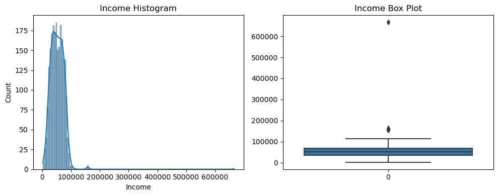

```
Upper whisker threshold for Income: 117416.25
```

```python
# Create a figure with two subplots for visualizing the 'Income' variable
plt.figure(figsize=(10, 4))

# Subplot 1: Histogram with Kernel Density Estimation (KDE)
plt.subplot(1, 2, 1)
sns.histplot(data['Income'], kde=True)
plt.title("Income Histogram")

# Subplot 2: Box Plot for 'Income'
plt.subplot(1, 2, 2)
sns.boxplot(data['Income'])
plt.title("Income Box Plot")

# Adjust the layout of the subplots for better visualization
plt.tight_layout()

# Display the plots
plt.show()

# Calculate the first quartile (Q1), third quartile (Q3), and interquartile range (IQR) for 'Income'
Q1 = data['Income'].quantile(0.25)
Q3 = data['Income'].quantile(0.75)
IQR = Q3 - Q1

# Calculate the upper whisker threshold for 'Income' based on the IQR
upper_whisker = Q3 + 1.5 * IQR
print("Upper whisker threshold for Income:", upper_whisker)
```

### **Bivariate Analysis**

- Analyze different categorical and numerical variables and check how different variables are related to each other.
- Check the relationship of numerical variables with categorical variables.

```python
# Fill missing values in the 'Income' column with the median income
median_income = data['Income'].median()
data['Income'].fillna(median_income, inplace=True)

# Calculate the 'Age' of customers based on the 'Year_Birth' column
data['Age'] = 2016 - data['Year_Birth']

# Calculate the 'Total_Kids' by adding the 'Kidhome' and 'Teenhome' columns
data['Total_Kids'] = data['Kidhome'] + data['Teenhome']

# Calculate the 'Family_Size' by adding 1 to the 'Total_Kids'
data['Family_Size'] = 1 + data['Kidhome'] + data['Teenhome']

# Calculate the 'Total_Spending' by summing up spending on various product categories
data['Total_Spending'] = data[['MntWines', 'MntFruits', 'MntMeatProducts', 'MntFishProducts', 'MntSweetProducts', 'MntGoldProds']].sum(axis=1)

# Convert the 'Dt_Customer' column to a datetime format and calculate 'Customer_Tenure' in days
data['Dt_Customer'] = pd.to_datetime(data['Dt_Customer'], format='%d-%m-%Y')
reference_date = datetime(2016, 1, 1)
data['Customer_Tenure'] = (reference_date - data['Dt_Customer']).dt.days

# Calculate 'Total_Offers_Accepted' by summing the accepted campaign columns
data['Total_Offers_Accepted'] = data[['AcceptedCmp1', 'AcceptedCmp2', 'AcceptedCmp3', 'AcceptedCmp4', 'AcceptedCmp5']].sum(axis=1)

# Calculate 'Amount_Spent_Per_Purchase' by dividing 'Total_Spending' by the total number of purchases
data['Amount_Spent_Per_Purchase'] = data['Total_Spending'] / (data['NumDealsPurchases'] + data['NumCatalogPurchases'] + data['NumStorePurchases'] + data['NumWebPurchases'])
```

### **Feature Engineering and Data Processing**

In this section, we will first prepare our dataset for analysis.

- Imputing missing values

**Think About It:**

- Can we extract the age of each customer and create a new feature?
- Can we find the total kids and teens in the home?
- Can we find out how many members each family has?
- Can we find the total amount spent by the customers on various products?
- Can we find out how long the customer has been with the company?
- Can we find out how many offers the customers have accepted?
- Can we find out amount spent per purchase?

```python
# 1. Extract Age of Each Customer
data['Age'] = 2016 - data['Year_Birth']

# 2. Total Kids and Teens in the Home
data['Total_Kids_Teens'] = data['Kidhome'] + data['Teenhome']

# 3. Total Family Members
data['Total_Family_Members'] = 1 + data['Kidhome'] + data['Teenhome']

# 4. Total Amount Spent on Various Products
product_columns = ['MntWines', 'MntFruits', 'MntMeatProducts', 'MntFishProducts', 'MntSweetProducts', 'MntGoldProds']
data['Total_Amount_Spent'] = data[product_columns].sum(axis=1)

# 5. Customer Tenure
data['Customer_Tenure'] = (pd.to_datetime('2016-01-01') - pd.to_datetime(data['Dt_Customer'])).dt.days

# 6. Total Offers Accepted
offer_columns = ['AcceptedCmp1', 'AcceptedCmp2', 'AcceptedCmp3', 'AcceptedCmp4', 'AcceptedCmp5']
data['Total_Offers_Accepted'] = data[offer_columns].sum(axis=1)

# 7. Amount Spent per Purchase
data['Amount_Spent_Per_Purchase'] = data['Total_Amount_Spent'] / (data['NumDealsPurchases'] + data['NumWebPurchases'] + data['NumCatalogPurchases'] + data['NumStorePurchases'])
```

## **Important Insights from EDA and Data Preprocessing**

What are the the most important observations and insights from the data based on the EDA and Data Preprocessing performed?

## **Data Preparation for Segmentation**

- The decision about which variables to use for clustering is a critically important decision that will have a big impact on the clustering solution. So we need to think carefully about the variables we will choose for clustering. Clearly, this is a step where a lot of contextual knowledge, creativity, and experimentation/iterations are needed.
- Moreover, we often use only a few of the data attributes for segmentation (the segmentation attributes) and use some of the remaining ones (the profiling attributes) only to profile the clusters. For example, in market research and market segmentation, we can use behavioral data for segmentation (to segment the customers based on their behavior like amount spent, units bought, etc.), and then use both demographic as well as behavioral data for profiling the segments found.
- Plot the correlation plot after we've removed the irrelevant variables
- Scale the Data

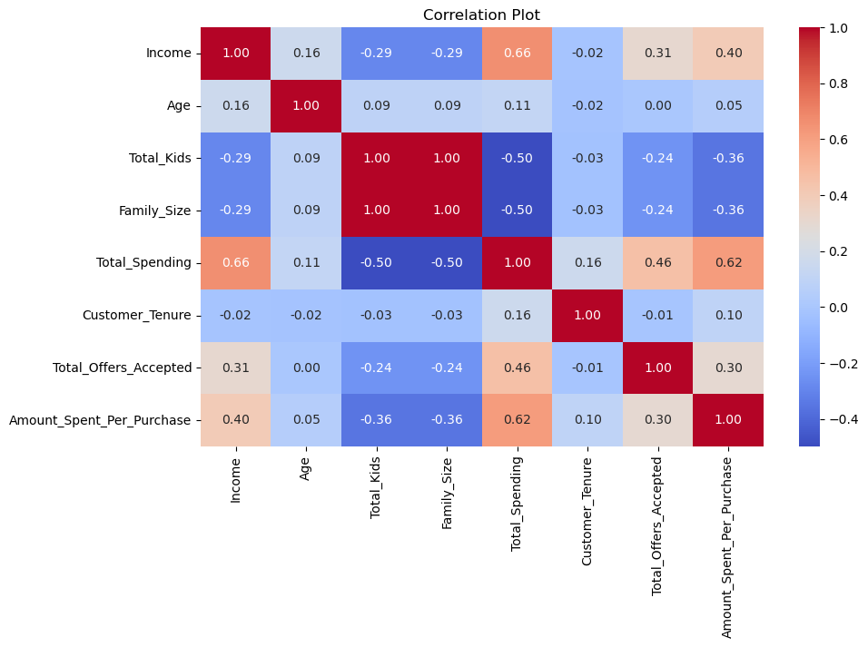

```python
# Step 1: Feature Selection for Clustering
selected_features = data[['Income', 'Age', 'Total_Kids', 'Family_Size', 'Total_Spending', 'Customer_Tenure', 'Total_Offers_Accepted', 'Amount_Spent_Per_Purchase']]

# Step 2: Correlation Plot
# Calculate the correlation matrix
correlation_matrix = selected_features.corr()

# Create a heatmap of the correlation matrix
plt.figure(figsize=(10, 6))
sns.heatmap(correlation_matrix, annot=True, cmap='coolwarm', fmt=".2f")
plt.title('Correlation Plot')
plt.show()
```

## **Applying T-SNE and PCA to the data to visualize the data distributed in 2 dimensions**

### **Applying T-SNE**

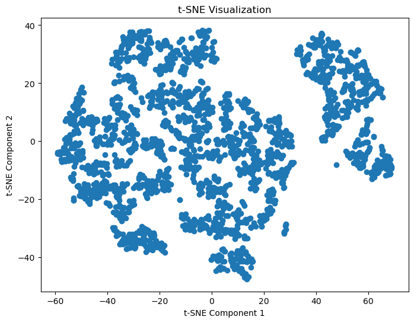

```python
# Define the features to be used for clustering
selected_features = ["Age", "Income", "Total_Spending", "Customer_Tenure", "Total_Offers_Accepted", "Amount_Spent_Per_Purchase"]

# Select the subset of data containing the selected features
data_subset = data[selected_features]

# Replace infinite values with NaN and fill missing values with the median of each column
data_subset = data_subset.replace([np.inf, -np.inf], np.nan)
data_subset = data_subset.fillna(data_subset.median())

# Initialize the StandardScaler to standardize the data
scaler = StandardScaler()

# Scale the data using the StandardScaler
data_subset_scaled = scaler.fit_transform(data_subset)

# Initialize t-SNE with 2 components and set a random state
tsne = TSNE(n_components=2, random_state=0)

# Apply t-SNE to the scaled data to obtain a 2D representation
data_2d = tsne.fit_transform(data_subset_scaled)

# Create a scatter plot for t-SNE visualization
plt.figure(figsize=(8, 6))
plt.scatter(data_2d[:, 0], data_2d[:, 1])
plt.title("t-SNE Visualization")
plt.xlabel("t-SNE Component 1")
plt.ylabel("t-SNE Component 2")
plt.show()
```

**Observation and Insights:**

there are three clusters visually but 2 of them are very close almost creating one large cluster. there seems to be a separation in one group in t-SNE 1. anything in the 50+ range.

### **Applying PCA**

**Think about it:**

- Should we apply clustering algorithms on the current data or should we apply PCA on the data before applying clustering algorithms? How would this help?

```python
# Select the features you want to apply PCA on
selected_features = ["Age", "Income", "Total_Spending", "Customer_Tenure", "Total_Offers_Accepted", "Amount_Spent_Per_Purchase"]


n_components = 3
pca = PCA(n_components=n_components)

data_pca = pca.fit_transform(data_subset_scaled)

# Create a subset of the data with the selected features
data_subset = data[selected_features]

# Replace infinite values (if any) with NaN and fill NaN values with the median
data_subset = data_subset.replace([np.inf, -np.inf], np.nan)
data_subset = data_subset.fillna(data_subset.median())

# Standardize the data
scaler = StandardScaler()
data_subset_scaled = scaler.fit_transform(data_subset)

# Specify the number of principal components you want to retain
n_components = 2  # You can choose a different number

# Create a PCA instance with the specified number of components
pca = PCA(n_components=n_components)

# Fit PCA to the scaled data and transform the data to the principal components
data_pca = pca.fit_transform(data_subset_scaled)

# The transformed data now contains the principal components

# You can access the explained variance ratio for each component
explained_variance_ratio = pca.explained_variance_ratio_
print("Explained Variance Ratio:", explained_variance_ratio)

# You can also access the principal components themselves
principal_components = pca.components_
print("Principal Components:", principal_components)
```

```
Explained Variance Ratio: [0.40602849 0.17607233]
Principal Components: [[ 0.11611122  0.4999248   0.58382544  0.08609533  0.39486872  0.48208663]
 [-0.6235444  -0.20219841  0.06686641  0.73945535  0.01135066  0.13752822]]
```

**Observation and Insights:**

PC1 is primarily associated with spending behavior and offers accepted by customers. It suggests that customers who spend more and accept more offers tend to have higher values on PC1. PC2, on the other hand, seems to capture information related to the customer's tenure (how long they have been with the company) and a negative relationship with income. This suggests that customers who have been with the company for a longer time and have lower income tend to have higher values on PC2

## **K-Means**

**Think About It:**

- How do we determine the optimal K value from the elbow curve?
- Which metric can be used to determine the final K value?

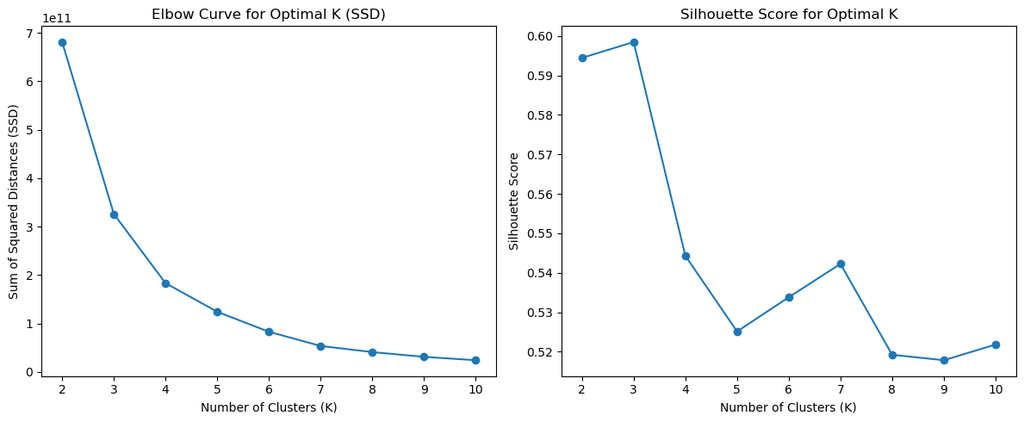

```python
# Define the features to be used for clustering
features_for_clustering = [
    "Income",
    "MntWines",
    "MntFruits",
    "MntMeatProducts",
    "MntFishProducts",
    "MntSweetProducts",
    "MntGoldProds",
]

# Select the data columns containing the specified features for clustering
data_for_clustering = data[features_for_clustering]

# Initialize empty lists to store SSD (Sum of Squared Distances) and silhouette scores
ssd = []
silhouette_scores = []

# Define a range of K values (number of clusters) to explore
K_range = range(2, 11)

# Iterate through each K value and perform K-Means clustering
for K in K_range:
    kmeans = KMeans(n_clusters=K, random_state=0)
    labels = kmeans.fit_predict(data_for_clustering)

    # Calculate and store the SSD (inertia) for the current K
    ssd.append(kmeans.inertia_)

    # Calculate the silhouette score and store it
    silhouette_avg = silhouette_score(data_for_clustering, labels)
    silhouette_scores.append(silhouette_avg)

# Create a figure with two subplots to visualize the Elbow Curve and Silhouette Score
plt.figure(figsize=(12, 5))

# Subplot 1: Elbow Curve for SSD
plt.subplot(1, 2, 1)
plt.plot(K_range, ssd, marker='o')
plt.title("Elbow Curve for Optimal K (SSD)")
plt.xlabel("Number of Clusters (K)")
plt.ylabel("Sum of Squared Distances (SSD)")

# Subplot 2: Silhouette Score
plt.subplot(1, 2, 2)
plt.plot(K_range, silhouette_scores, marker='o')
plt.title("Silhouette Score for Optimal K")
plt.xlabel("Number of Clusters (K)")
plt.ylabel("Silhouette Score")

# Adjust the layout for better visualization
plt.tight_layout()

# Display the plots
plt.show()
```

### **Applying KMeans on the PCA data and visualize the clusters**

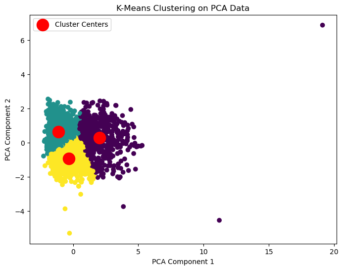

```python
# Initialize K-Means clustering with 3 clusters and a specified random state
kmeans = KMeans(n_clusters=3, random_state=0)

# Perform K-Means clustering on the data in the PCA (Principal Component Analysis) space
labels = kmeans.fit_predict(data_pca)

# Create a scatter plot to visualize the K-Means clustering results in the PCA space
plt.figure(figsize=(8, 6))
plt.scatter(data_pca[:, 0], data_pca[:, 1], c=labels, cmap='viridis')
plt.title("K-Means Clustering on PCA Data")
plt.xlabel("PCA Component 1")
plt.ylabel("PCA Component 2")

# Get the cluster centers and add them to the plot
cluster_centers = kmeans.cluster_centers_
plt.scatter(cluster_centers[:, 0], cluster_centers[:, 1], s=300, c='red', label='Cluster Centers')

# Add a legend to the plot
plt.legend()
plt.show()
```

### **Cluster Profiling**

```python
# Create a DataFrame to store the clustered data in the first two PCA components and cluster labels
clustered_data = pd.DataFrame(data_pca[:, :2], columns=['PCA Component 1', 'PCA Component 2'])
clustered_data['Cluster Labels'] = labels

# Group the data by cluster labels
cluster_groups = clustered_data.groupby('Cluster Labels')

# Calculate the cluster profiles, including the mean values of PCA components and the number of data points in each cluster
cluster_profiles = cluster_groups[['PCA Component 1', 'PCA Component 2']].mean()
cluster_profiles['Number of Data Points'] = cluster_groups.size()

# Print the cluster profiles
print("Cluster Profiles:")
print(cluster_profiles)

# Get the cluster centers from K-Means
cluster_centers = kmeans.cluster_centers_

# Print the cluster centers
print("\nCluster Centers:")
print(cluster_centers)
```

```
Cluster Profiles:
                PCA Component 1  PCA Component 2  Number of Data Points
Cluster Labels
0                      2.028992         0.288148                    598
1                     -1.115772         0.631756                    870
2                     -0.314269        -0.935155                    772

Cluster Centers:
[[ 2.03086774  0.28932313]
 [-1.11577182  0.63175565]
 [-0.31268636 -0.93448037]]
```

**Observations and Insights:**

the K-Means algorithm has clustered the data into 3 groups, as Cluster 0, Cluster 1, and Cluster 2, based on the values of the PCA components.To gain a deeper understanding of these clusters, it's advisable to analyze the distribution of the original features within each cluster. This helps in defining the characteristics and behaviors of the data points in each cluster.

### **Describe the characteristics of each cluster**

**Think About It:**

- Are the K-Means profiles providing any deep insights into customer purchasing behavior or which channels they are using?
- What is the next step to get more meaningful insights?

**Summary of each cluster:**

## **K-Medoids**

```python
# Define the features to be used for preprocessing and clustering
selected_features = ["Income", "MntWines", "MntFruits", "MntMeatProducts", "MntFishProducts", "MntSweetProducts"]

# Select the data columns containing the specified features
data_subset = data[selected_features]

# Fill missing values in the selected features with the median of each column
data_subset = data_subset.fillna(data_subset.median())

# Initialize the StandardScaler to standardize the data
scaler = StandardScaler()

# Scale the data using the StandardScaler
data_subset_scaled = scaler.fit_transform(data_subset)

# Perform Principal Component Analysis (PCA) to reduce data to 2 components
pca = PCA(n_components=2)
data_pca = pca.fit_transform(data_subset_scaled)

# Define the number of clusters (in this case, 3)
num_clusters = 3

# Initialize KMedoids clustering with the specified number of clusters
kmedoids = KMedoids(n_clusters=num_clusters, random_state=0)

# Perform KMedoids clustering on the PCA-transformed data
cluster_labels = kmedoids.fit_predict(data_pca)

# Add a 'Cluster' column to the original data to store cluster labels
data['Cluster'] = cluster_labels

# Calculate cluster profiles (mean values of each feature for each cluster)
cluster_profiles = data.groupby('Cluster').mean()

# Get the medoids (cluster centers) from KMedoids
medoids = kmedoids.cluster_centers_
```

### **Visualize the clusters using PCA**

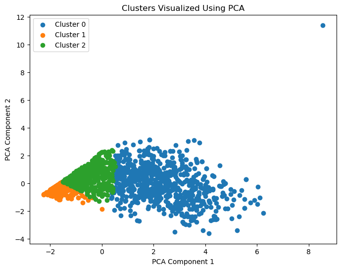

```python
# Define the features to be used for preprocessing and clustering
selected_features = ["Income", "MntWines", "MntFruits", "MntMeatProducts", "MntFishProducts", "MntSweetProducts"]

# Select the data columns containing the specified features
data_subset = data[selected_features]

# Fill missing values in the selected features with the median of each column
data_subset = data_subset.fillna(data_subset.median())

# Initialize the StandardScaler to standardize the data
scaler = StandardScaler()

# Scale the data using the StandardScaler
data_subset_scaled = scaler.fit_transform(data_subset)

# Perform Principal Component Analysis (PCA) to reduce data to 2 components
pca = PCA(n_components=2)
data_pca = pca.fit_transform(data_subset_scaled)

# Define the number of clusters (in this case, 3)
num_clusters = 3

# Initialize KMedoids clustering with the specified number of clusters
kmedoids = KMedoids(n_clusters=num_clusters, random_state=0)

# Perform KMedoids clustering on the scaled data
cluster_labels = kmedoids.fit_predict(data_subset_scaled)

# Add a 'Cluster' column to the original data to store cluster labels
data['Cluster'] = cluster_labels

# Create a scatter plot to visualize clusters in the PCA space
plt.figure(figsize=(8, 6))

# Loop through cluster IDs and plot each cluster separately
for cluster_id in range(num_clusters):
    cluster_data = data_pca[data['Cluster'] == cluster_id]
    plt.scatter(cluster_data[:, 0], cluster_data[:, 1], label=f'Cluster {cluster_id}')

plt.title("Clusters Visualized Using PCA")
plt.xlabel("PCA Component 1")
plt.ylabel("PCA Component 2")
plt.legend()
plt.show()
```

### **Cluster Profiling**

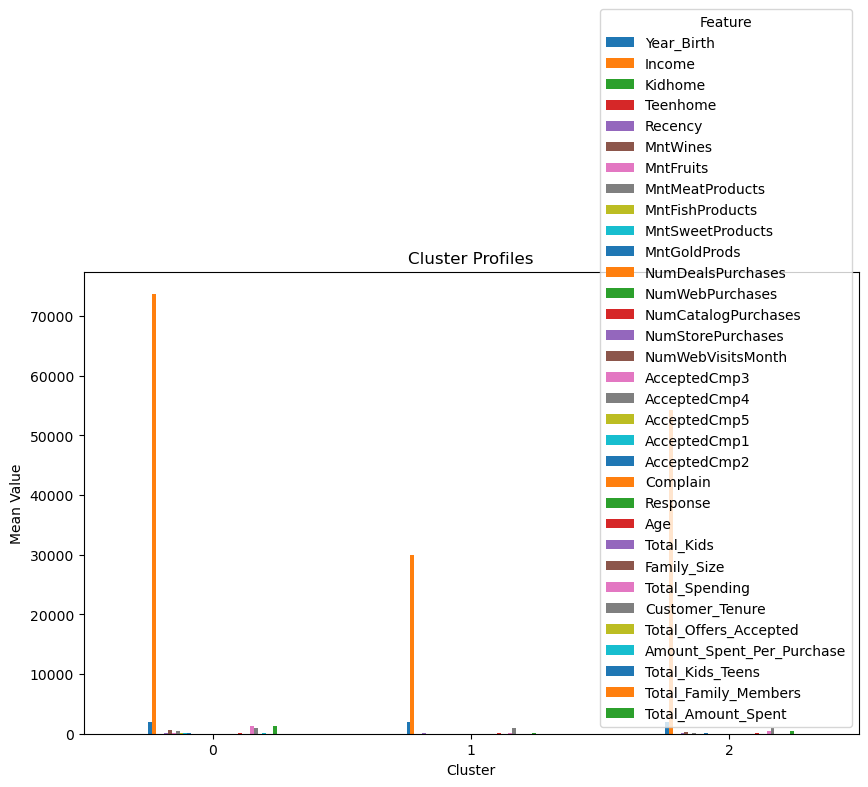

```
          Year_Birth        Income   Kidhome  Teenhome    Recency    MntWines  \
Cluster
0        1967.558710  73710.050323  0.083871  0.348387  49.707097  602.549677
1        1972.833540  29897.654658  0.828571  0.376398  48.947826   24.554037
2        1965.357576  54272.975758  0.398485  0.850000  48.604545  294.051515

         MntFruits  MntMeatProducts  MntFishProducts  MntSweetProducts  ...  \
Cluster                                                                 ...
0        62.784516       398.633548        89.585806         65.000000  ...
1         4.566460        18.376398         6.421118          4.623602  ...
2         9.974242        76.112121        14.331818          9.884848  ...

               Age  Total_Kids  Family_Size  Total_Spending  Customer_Tenure  \
Cluster
0        48.441290    0.432258     1.432258     1294.357419       926.775484
1        43.166460    1.204969     2.204969       73.463354       885.206211
2        50.642424    1.248485     2.248485      446.550000       902.154545

         Total_Offers_Accepted  Amount_Spent_Per_Purchase  Total_Kids_Teens  \
Cluster
0                     0.579355                  64.963475          0.432258
1                     0.084472                        NaN          1.204969
2                     0.225758                        NaN          1.248485

         Total_Family_Members  Total_Amount_Spent
Cluster
0                    1.432258         1294.357419
1                    2.204969           73.463354
2                    2.248485          446.550000

[3 rows x 33 columns]
```

```python
# Group the data by cluster labels
cluster_groups = data.groupby('Cluster')

# Calculate the cluster profiles (mean values of each feature for each cluster)
cluster_profiles = cluster_groups.mean()

# Create a bar plot to visualize the cluster profiles
cluster_profiles.plot(kind='bar', figsize=(10, 6))
plt.title("Cluster Profiles")
plt.xlabel("Cluster")
plt.ylabel("Mean Value")
plt.xticks(rotation=0)
plt.legend(title='Feature')
plt.show()

# Print the cluster profiles
print(cluster_profiles)
```

**Observations and Insights:**

### **Characteristics of each cluster**

**Summary for each cluster:**

**Observations and Insights:**

Cluster 0 represent a segment of customers with unique purchasing behavior, as it shows higher values for PCA Component 1. Further analysis is needed to identify the specific characteristics that define this cluster. Cluster 1, being the largest cluster, represents a relatively more general group of customers. The values of PCA components indicate some differences from Cluster 0 and Cluster 2. Cluster 2 displays unique behavior with lower values for PCA Component 1 and a negative value for PCA Component 2. Understanding the characteristics of this cluster is essential for targeted marketing.

## **Hierarchical Clustering**

- Find the Cophenetic correlation for different distances with different linkage methods.
- Create the dendrograms for different linkages
- Explore different linkages with each distance metric

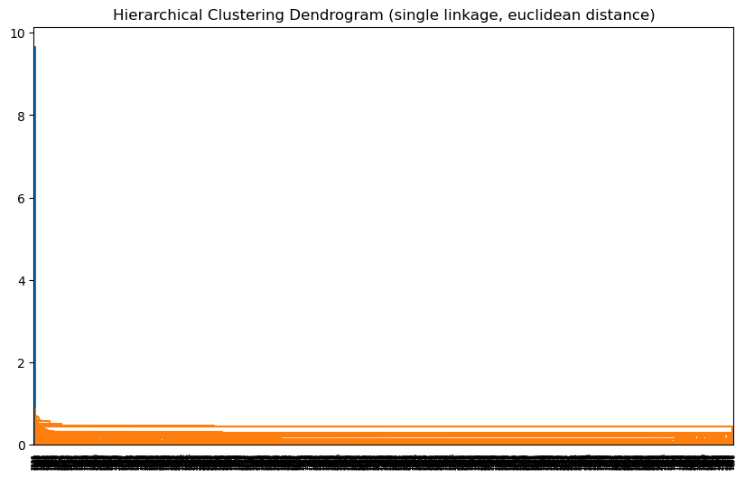

```
Cophenetic Correlation (single linkage, euclidean distance): 0.42508757556102766
```

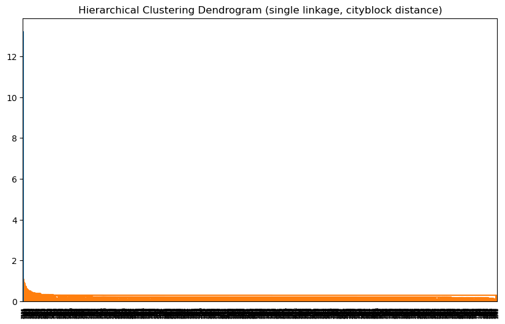

```
Cophenetic Correlation (single linkage, cityblock distance): 0.4428844786619659
```

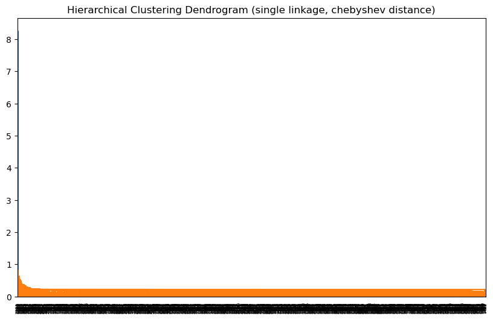

```
Cophenetic Correlation (single linkage, chebyshev distance): 0.3859168508021466
```

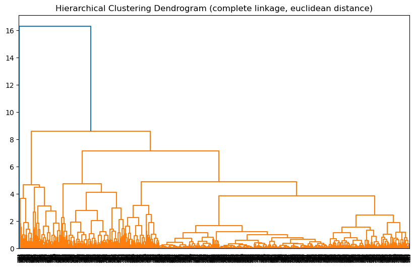

```
Cophenetic Correlation (complete linkage, euclidean distance): 0.8289355433533379
```

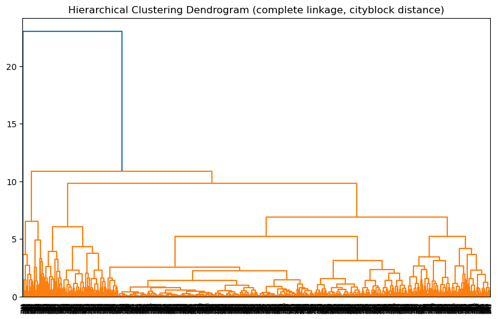

```
Cophenetic Correlation (complete linkage, cityblock distance): 0.7863557341800713
```

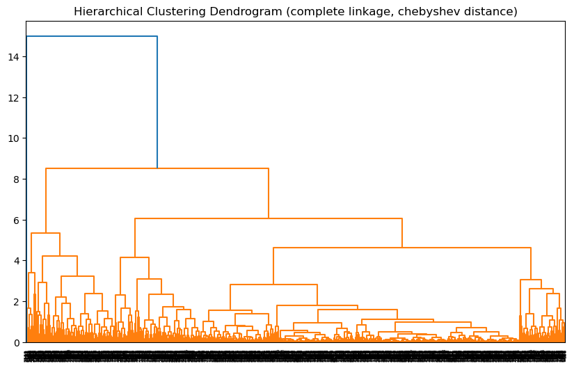

```
Cophenetic Correlation (complete linkage, chebyshev distance): 0.8255230488382573
```

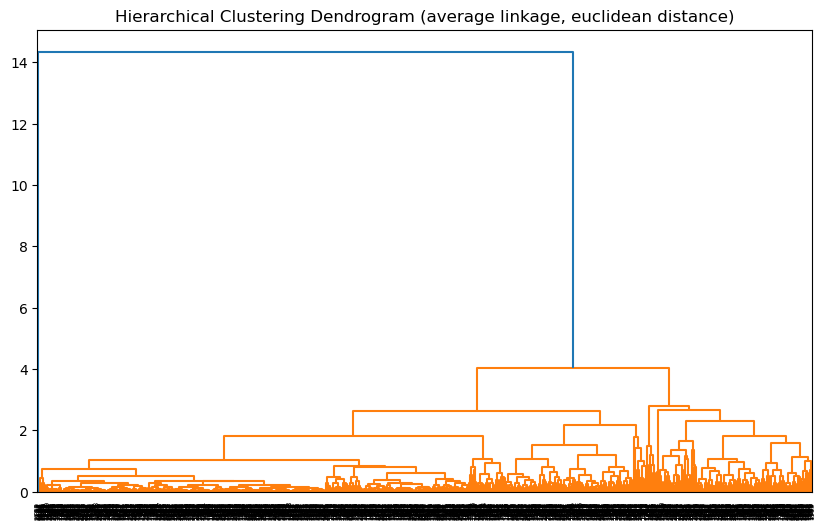

```
Cophenetic Correlation (average linkage, euclidean distance): 0.8335424636457632
```

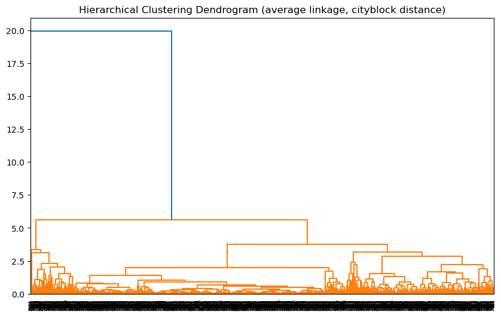

```
Cophenetic Correlation (average linkage, cityblock distance): 0.8392044941657558
```

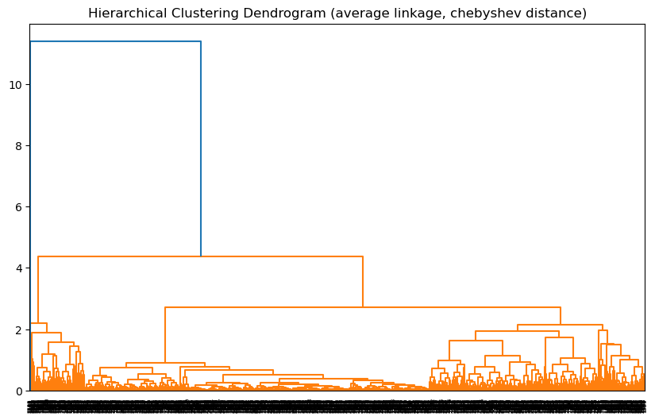

```
Cophenetic Correlation (average linkage, chebyshev distance): 0.820437623642685
```

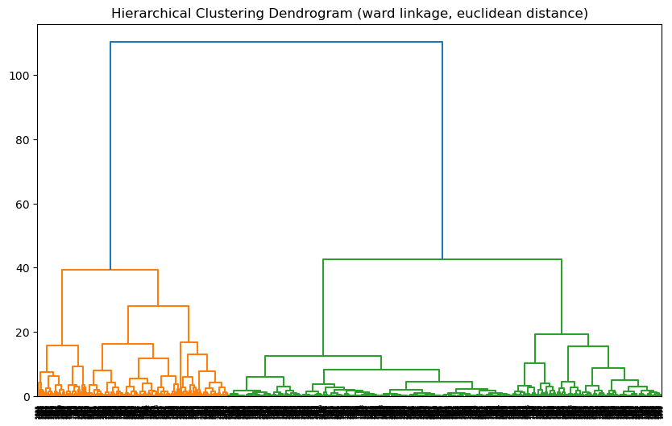

```
Cophenetic Correlation (ward linkage, euclidean distance): 0.7794847527744698
```

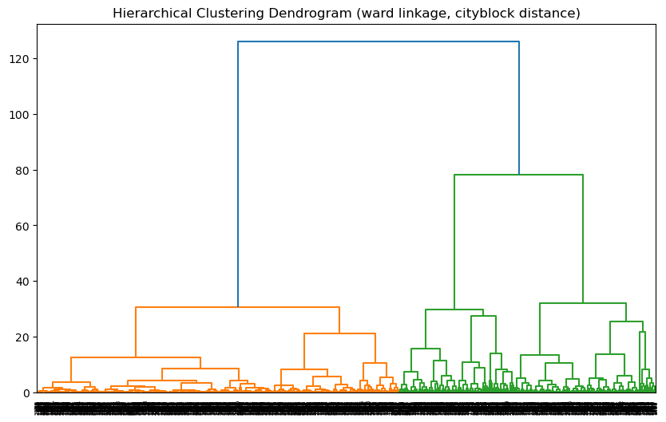

```
Cophenetic Correlation (ward linkage, cityblock distance): 0.7130315428107904
```

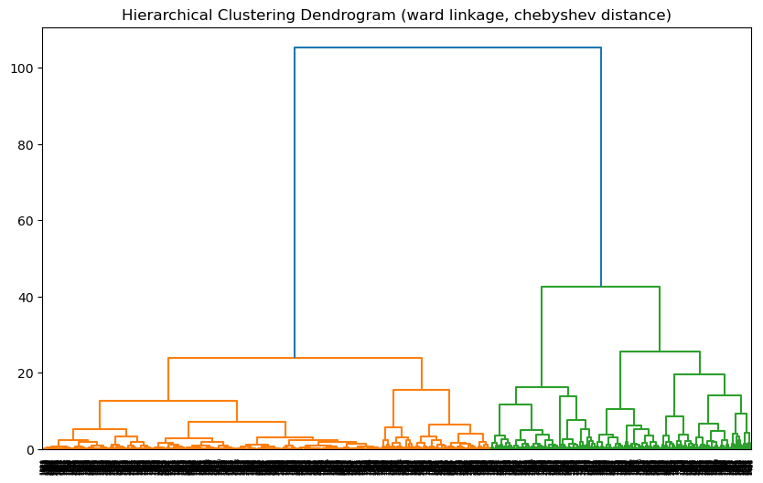

```
Cophenetic Correlation (ward linkage, chebyshev distance): 0.7586568553719687
```

```python
# Define distance metrics to calculate pairwise distances between data points
distances = {
    'euclidean': pdist(data_pca, metric='euclidean'),
    'cityblock': pdist(data_pca, metric='cityblock'),
    'chebyshev': pdist(data_pca, metric='chebyshev'),
}

# Define linkage methods to use in hierarchical clustering
linkage_methods = ['single', 'complete', 'average', 'ward']

# Iterate through each linkage method and distance metric
for linkage_method in linkage_methods:
    for distance_metric, distance_matrix in distances.items():
        # Calculate the hierarchical clustering using the specified linkage method and distance metric
        Z = sch.linkage(distance_matrix, method=linkage_method)

        # Calculate the cophenetic correlation and distance
        coph_corr, coph_dist = cophenet(Z, distance_matrix)

        # Create a dendrogram to visualize the hierarchical clustering
        plt.figure(figsize=(10, 6))
        plt.title(f"Hierarchical Clustering Dendrogram ({linkage_method} linkage, {distance_metric} distance)")
        dendrogram = sch.dendrogram(Z)
        plt.show()

        # Print the cophenetic correlation for the current linkage method and distance metric
        print(f"Cophenetic Correlation ({linkage_method} linkage, {distance_metric} distance): {coph_corr}")
```

**Think about it:**

- Can we clearly decide the number of clusters based on where to cut the dendrogram horizontally?
- What is the next step in obtaining number of clusters based on the dendrogram?
- Are there any distinct clusters in any of the dendrograms?

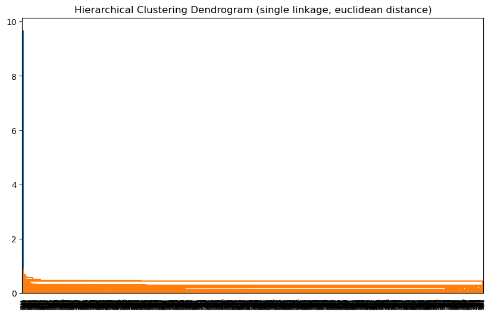

```
Cophenetic Correlation (single linkage, euclidean distance): 0.42508757556102766
```

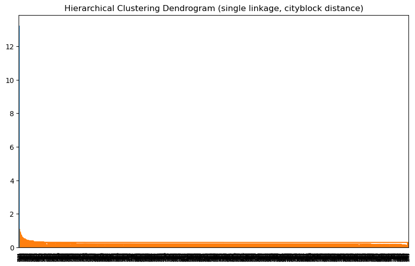

```
Cophenetic Correlation (single linkage, cityblock distance): 0.4428844786619659
```

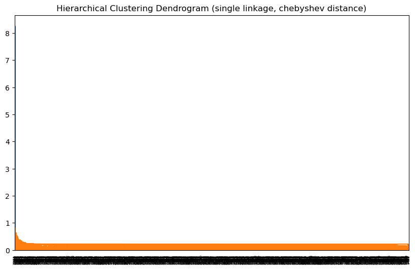

```
Cophenetic Correlation (single linkage, chebyshev distance): 0.3859168508021466
```

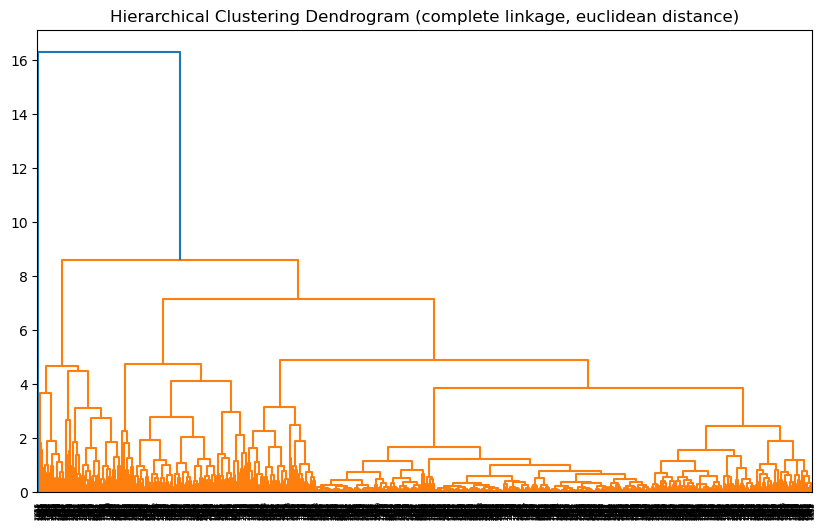

```
Cophenetic Correlation (complete linkage, euclidean distance): 0.8289355433533379
```

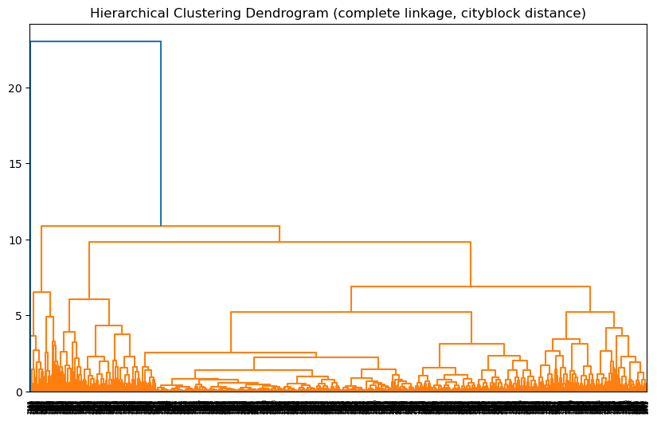

```
Cophenetic Correlation (complete linkage, cityblock distance): 0.7863557341800713
```

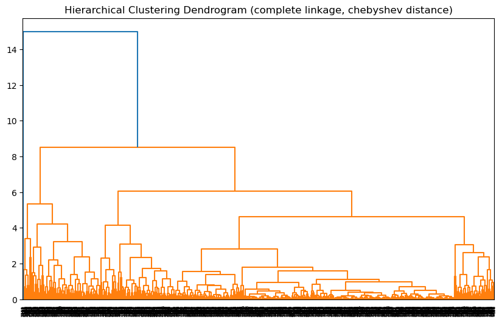

```
Cophenetic Correlation (complete linkage, chebyshev distance): 0.8255230488382573
```

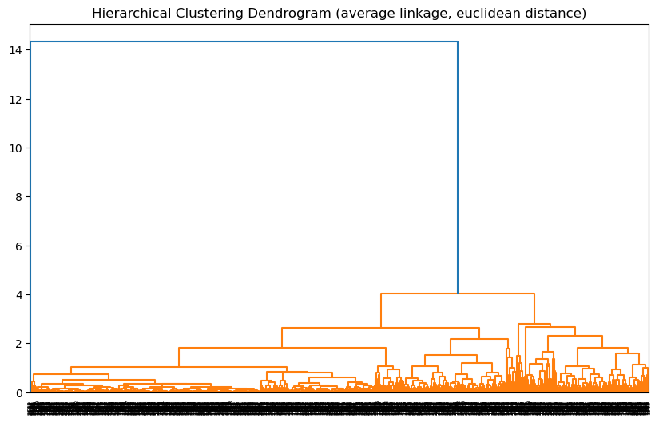

```
Cophenetic Correlation (average linkage, euclidean distance): 0.8335424636457632
```

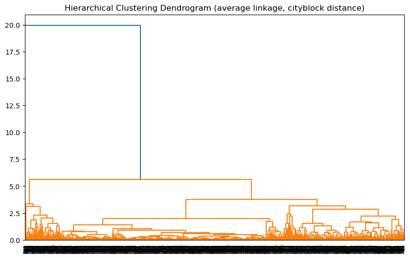

```
Cophenetic Correlation (average linkage, cityblock distance): 0.8392044941657558
```

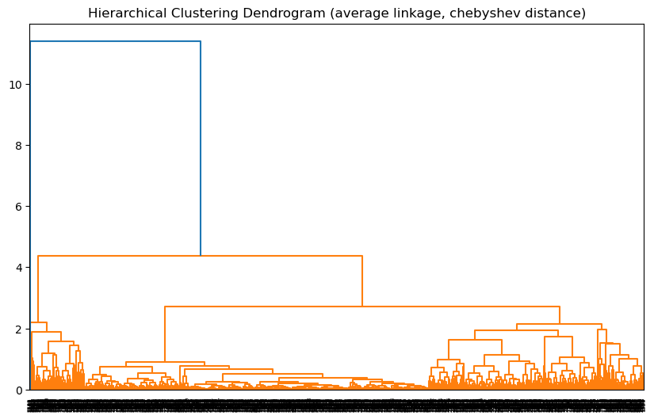

```
Cophenetic Correlation (average linkage, chebyshev distance): 0.820437623642685
```

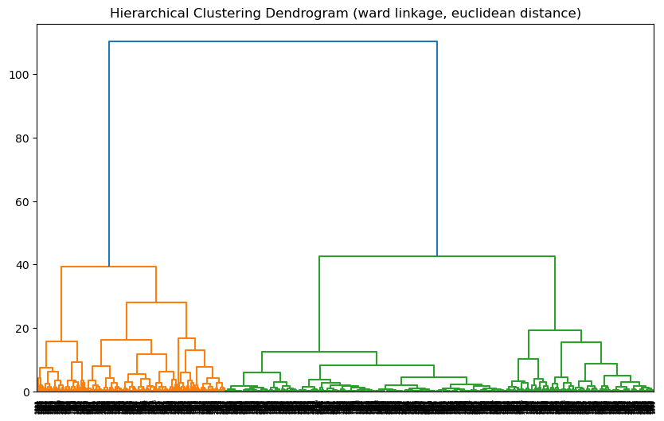

```
Cophenetic Correlation (ward linkage, euclidean distance): 0.7794847527744698
```

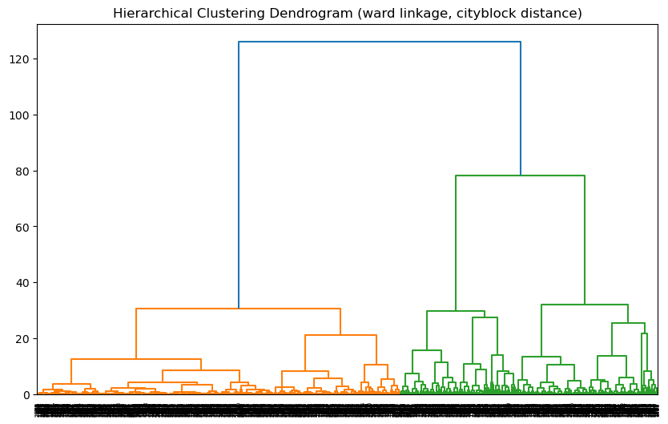

```
Cophenetic Correlation (ward linkage, cityblock distance): 0.7130315428107904
```

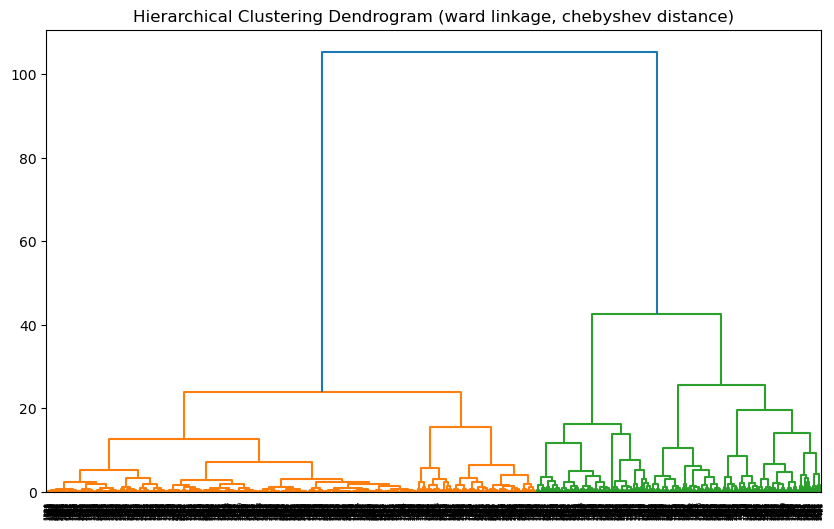

```
Cophenetic Correlation (ward linkage, chebyshev distance): 0.7586568553719687
```

```python
# Define distance metrics to calculate pairwise distances between data points
distances = {
    'euclidean': pdist(data_pca, metric='euclidean'),
    'cityblock': pdist(data_pca, metric='cityblock'),
    'chebyshev': pdist(data_pca, metric='chebyshev'),
}

# Define linkage methods to use in hierarchical clustering
linkage_methods = ['single', 'complete', 'average', 'ward']

# Iterate through each linkage method and distance metric
for linkage_method in linkage_methods:
    for distance_metric, distance_matrix in distances.items():
        # Calculate the hierarchical clustering using the specified linkage method and distance metric
        Z = sch.linkage(distance_matrix, method=linkage_method)

        # Calculate the cophenetic correlation and distance
        coph_corr, coph_dist = cophenet(Z, distance_matrix)

        # Create a dendrogram to visualize the hierarchical clustering
        plt.figure(figsize=(10, 6))
        plt.title(f"Hierarchical Clustering Dendrogram ({linkage_method} linkage, {distance_metric} distance)")
        dendrogram = sch.dendrogram(Z)
        plt.show()

        # Print the cophenetic correlation for the current linkage method and distance metric
        print(f"Cophenetic Correlation ({linkage_method} linkage, {distance_metric} distance): {coph_corr}")
```

### **Cluster Profiling**

```python
# Create a copy of the original data with cluster labels
data_with_clusters = data.copy()
data_with_clusters['Cluster'] = cluster_labels

# Group the data by cluster labels
cluster_groups = data_with_clusters.groupby('Cluster')

# Calculate the cluster profiles (mean values of each feature for each cluster)
cluster_profiles = cluster_groups.mean()

# Print the cluster profiles
print(cluster_profiles)
```

```
          Year_Birth        Income   Kidhome  Teenhome    Recency    MntWines  \
Cluster
0        1967.558710  73710.050323  0.083871  0.348387  49.707097  602.549677
1        1972.833540  29897.654658  0.828571  0.376398  48.947826   24.554037
2        1965.357576  54272.975758  0.398485  0.850000  48.604545  294.051515

         MntFruits  MntMeatProducts  MntFishProducts  MntSweetProducts  ...  \
Cluster                                                                 ...
0        62.784516       398.633548        89.585806         65.000000  ...
1         4.566460        18.376398         6.421118          4.623602  ...
2         9.974242        76.112121        14.331818          9.884848  ...

               Age  Total_Kids  Family_Size  Total_Spending  Customer_Tenure  \
Cluster
0        48.441290    0.432258     1.432258     1294.357419       926.775484
1        43.166460    1.204969     2.204969       73.463354       885.206211
2        50.642424    1.248485     2.248485      446.550000       902.154545

         Total_Offers_Accepted  Amount_Spent_Per_Purchase  Total_Kids_Teens  \
Cluster
0                     0.579355                  64.963475          0.432258
1                     0.084472                        NaN          1.204969
2                     0.225758                        NaN          1.248485

         Total_Family_Members  Total_Amount_Spent
Cluster
0                    1.432258         1294.357419
1                    2.204969           73.463354
2                    2.248485          446.550000

[3 rows x 33 columns]
```

**Observations and Insights:** Cluster 0 appears to be a high-income segment with potential for more targeted marketing efforts to increase responses. Cluster 1 represents a lower-income segment with families, which may require specialized marketing strategies. Cluster 2 is a moderate-income segment with a significant presence of teenagers, which could be targeted with relevant offers and campaigns.

## **DBSCAN**

DBSCAN is a very powerful algorithm for finding high-density clusters, but the problem is determining the best set of hyperparameters to use with it. It includes two hyperparameters, `eps`, and `min samples`.

Since it is an unsupervised algorithm, you have no control over it, unlike a supervised learning algorithm, which allows you to test your algorithm on a validation set. The approach we can follow is basically trying out a bunch of different combinations of values and finding the silhouette score for each of them.

```python
# Initialize variables to store the best parameters and silhouette score
best_eps = 0
best_min_samples = 0
best_silhouette_score = -1

# Loop through a range of epsilon (eps) values and minimum samples (min_samples)
for eps in np.arange(0.1, 2.0, 0.1):
    for min_samples in range(2, 10):
        # Create a DBSCAN clustering instance with the current parameters
        dbscan = DBSCAN(eps=eps, min_samples=min_samples)

        # Fit the DBSCAN model and get cluster labels
        dbscan_clusters = dbscan.fit_predict(data_pca)

        # Check if there is more than one cluster (len(set(dbscan_clusters) > 1)
        if len(set(dbscan_clusters)) > 1:
            # Calculate the silhouette score for the current clustering
            silhouette_avg = silhouette_score(data_pca, dbscan_clusters)

            # Update the best parameters and silhouette score if the current score is better
            if silhouette_avg > best_silhouette_score:
                best_eps = eps
                best_min_samples = min_samples
                best_silhouette_score = silhouette_avg

# Print the best parameters and silhouette score
print(f"Best eps: {best_eps}")
print(f"Best min_samples: {best_min_samples}")
print(f"Best Silhouette Score: {best_silhouette_score}")
```

```
Best eps: 0.9
Best min_samples: 2
Best Silhouette Score: 0.8286405515588718
```